# TORC1関連変異株におけるAde4顆粒形成効率の解析

MT

2022-10-28

# 1 この事例で扱うデータと統計

**カテゴリ変数**：`strain`（WT, sfp1∆, sit4∆）  
**数値変数**： Ade4顆粒を持つ細胞の割合（%）`pct_foci_cell`  
**グラフ**：棒グラフ（平均） + エラーバー（1SD） + ドットプロット（各データポイント）  
**統計**：Dunnettの多重検定（パラメトリック）、Shapiro-Wilk検定による正規性の検証、Steelの多重検定（ノンパラメトリック）

# 2 データの取得と読み込み

TORC1の下流因子であるSfp1とSit4の遺伝子破壊株におけるAde4顆粒形成を観察、野生株と顆粒形成効率を比較する。蛍光顕微鏡観察後、画像処理により顆粒を持つ細胞の割合を計測し、csvファイルで出力。

```r
library(pacman)
p_load(tidyverse, openxlsx, readxl, ggtext, multcomp, ggsignif, knitr, nparcomp, rstatix, dunn.test)  # パッケージをまとめてロード
```

顆粒をFIJIのFindMaxima関数で検出する際のパラメータ `prominence`を3種類設定して解析。それぞれのデータを別々のフォルダに保存。

```r
import_file_path_prom750 <- "prom_750" # prominence=750, 3回の実験から得られたfoci_stat.csvをまとめたフォルダ
import_file_path_prom875 <- "prom_875"
import_file_path_prom1000 <- "prom_1000"
```

```r
# 拡張子が.csvのファイルのリストをフルネームで取得（実際はtxtファイル）
csv_list_prom750 <- list.files(import_file_path_prom750, full.names = T, pattern = "*.csv")
csv_list_prom875 <- list.files(import_file_path_prom875, full.names = T, pattern = "*.csv")
csv_list_prom1000 <- list.files(import_file_path_prom1000, full.names = T, pattern = "*.csv")
```

論文には`prominence` = 750のデータを使用。 `spply()`を使い、ファイル名リストから全てのファイルを一括で読み込み、データフレームのリストを作成。さらに`bind_rows()`でデータフレームを縦に連結して１つにする。

```r
foci_stat <- csv_list_prom750 %>%
  sapply(., read.csv, header =TRUE, sep = ",", stringsAsFactors = FALSE, simplify = FALSE) %>% #「.」でcsv_listの位置を明示
  bind_rows()
foci_stat <- as_tibble(foci_stat)  # tibble形式にしておく
```

株を表す変数`strain`を作成する

```r
foci_stat <-
  foci_stat %>%
  mutate(strain =case_when(
    str_detect(file_name, "wt") ~ "WT",
    str_detect(file_name, "sfp1") ~ "sfp1∆",
    TRUE ~ "sit4∆"))  # 上2つの条件に当てはまらない場合

foci_stat$strain <- as_factor(foci_stat$strain)
# この時点ではstrainが文字列型なのでfactor型に変換しておく、文字列型のママだと多重検定でエラーになる
foci_stat$strain <- fct_relevel(foci_stat$strain, c("WT", "sfp1∆", "sit4∆"))  ## fct_relevelでレベル順を変更
foci_stat
```

```
## # A tibble: 81 × 8
##        X file_name         total_cell_n…¹ foci_…² pct_f…³ promi…⁴ defocus strain
##    <int> <chr>                      <int>   <int>   <dbl>   <int> <lgl>   <fct>
##  1     1 Ade4_mNG_sfp1_017            627     135    21.5     750 NA      sfp1∆
##  2     2 Ade4_mNG_sfp1_018            401     119    29.7     750 NA      sfp1∆
##  3     3 Ade4_mNG_sfp1_019            423     125    29.6     750 NA      sfp1∆
##  4     4 Ade4_mNG_sfp1_020            251     129    51.4     750 NA      sfp1∆
##  5     5 Ade4_mNG_sfp1_021            467     272    58.2     750 NA      sfp1∆
##  6     6 Ade4_mNG_sfp1_022            446     259    58.1     750 NA      sfp1∆
##  7     7 Ade4_mNG_sfp1_023            560     290    51.8     750 NA      sfp1∆
##  8     8 Ade4_mNG_sfp1_024            578     268    46.4     750 NA      sfp1∆
##  9     9 Ade4_mNG_sfp1_025            523     250    47.8     750 NA      sfp1∆
## 10    10 Ade4_mNG_sfp1_026            512     230    44.9     750 NA      sfp1∆
## # … with 71 more rows, and abbreviated variable names ¹total_cell_number,
## #   ²foci_cell, ³pct_foci_cell, ⁴prominence
```

# 3 データの集計

視野内で顆粒を持つ細胞の割合（%）を表す変数`pct_foci_cell`の平均とSDを求める。また1ｘSDに相当するerror barを書くための範囲を設定。結果をExcelファイルとして保存。

```r
mean_sd <- foci_stat %>%
  group_by(strain) %>%
  summarise(mean = mean(pct_foci_cell), sd = sd(pct_foci_cell), N=n())
limits <- aes(ymax = mean + sd, ymin = mean - sd)
write.xlsx(mean_sd, "mean_sd.xlsx", colNames = TRUE, sheetName = "221026_tormut")
```

# 4 統計検定

```r
# strain間で分散分析
res_aov <- aov(pct_foci_cell ~ strain, data = foci_stat)
summary(res_aov)
```

```
##             Df Sum Sq Mean Sq F value   Pr(>F)
## strain       2  23516   11758   30.57 1.58e-10 ***
## Residuals   78  30005     385
## ---
## Signif. codes:  0 '***' 0.001 '**' 0.01 '*' 0.05 '.' 0.1 ' ' 1
```

```r
res_dn <- glht(res_aov, linfct = mcp(strain = "Dunnett"), alternative = "two.sided")
summary(res_dn)
```

```
##
##   Simultaneous Tests for General Linear Hypotheses
##
## Multiple Comparisons of Means: Dunnett Contrasts
##
##
## Fit: aov(formula = pct_foci_cell ~ strain, data = foci_stat)
##
## Linear Hypotheses:
##                 Estimate Std. Error t value Pr(>|t|)
## sfp1∆ - WT == 0  -39.160      5.440  -7.199 6.57e-10 ***
## sit4∆ - WT == 0  -33.447      5.297  -6.314 3.07e-08 ***
## ---
## Signif. codes:  0 '***' 0.001 '**' 0.01 '*' 0.05 '.' 0.1 ' ' 1
## (Adjusted p values reported -- single-step method)
```

# 5 データの可視化

顆粒を持つ細胞の割合の平均値を棒グラフで、1SDをエラーバーで描画。個々のデータ点もプロット。検定の結果も表示。

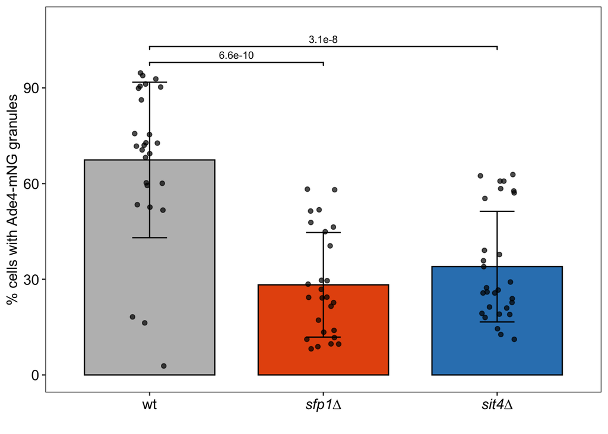

```r
# 検定結果のp値をマニュアルでアノテーションするのに必要なオブジェクトを作成
  annot1 = c("6.6e-10", "3.1e-8")
  y_position = c(98,103)
  xmin = c(1, 1)
  xmax = c(2, 3)

  plot1 <- mean_sd %>% ggplot(aes(x= strain, y=mean))+
    geom_bar(aes(fill=strain),stat="identity", color="black", # colorは枠線の色
             width = 0.75, position = position_dodge(width = 0.6)) + # widthでバーの幅
  geom_errorbar(limits, width = 0.2, position = position_dodge(width=0.6)) +
  geom_signif(xmin = xmin, xmax =xmax, y_position =y_position, annotation = annot1, textsize = 3, tip_length = 0.01) +
  scale_fill_manual(values = c('#bdbdbd',"#e6550d","#3182bd"))+
  geom_jitter(foci_stat, mapping=aes(x=strain, y= pct_foci_cell),size = 1.5,
              alpha=0.7, width = 0.1, height = 0)+
  # ggtextを使用すると*で囲むと斜体になる、labelsを指定
  scale_x_discrete(labels=c("wt", "*sfp1∆*", "*sit4∆*")) +
  ylab("% cells with Ade4-mNG granules") +   ## y軸のラベル
  xlab("")+                   ## x軸のラベル
  ylim(0,110)+                  ## y軸のレンジ
  theme( axis.title.y = element_text(size=12), axis.text.y = element_text(size=12,color = "black"),
         # ggtextを使用する場合はelement_markdownで指定
         axis.text.x = element_markdown(size = 12,colour = "black")
         ,legend.position = "none" #凡例を消す
         ,panel.border = element_rect(fill = NA, size = 0.5) # パネルを枠で囲む
         ,panel.background = element_blank()) #背景を白にする
plot1
```

# 6 正規性の検証

全てのデータが正規分布に従っていると仮定して統計検定を行ったが、プロットを見る限り、正規分布とは言い難い。そこでShapiro-Wilk検定でデータの正規性を検証する。

```r
# strainの種類をベクトルとして取り出しておく
strains <- levels(foci_stat$strain)
# あるstrainの値に対応するpct_foci_cellの値の分布をshapiro.test()で検定するための関数を作成
st <- function(astrain) {foci_stat %>%
  filter(strain == astrain) %>%
  dplyr::select(pct_foci_cell) %>%
  as_vector() %>%
  shapiro.test()}
st("WT") # 関数のテスト
```

```
##
##  Shapiro-Wilk normality test
##
## data:  .
## W = 0.86297, p-value = 0.002566
```

```r
st_result <- lapply(strains, st)
names(st_result) <- strains  # リストの要素の名前をつける
```

結果をテキストファイルに保存。

```r
sink("result_shapiro_test.txt")
for (astrain in strains){   # st_resultの要素を順番にコンソールに表示
  print(st_result[astrain])
}
```

```
## $WT
##
##  Shapiro-Wilk normality test
##
## data:  .
## W = 0.86297, p-value = 0.002566
##
##
## $`sfp1∆`
##
##  Shapiro-Wilk normality test
##
## data:  .
## W = 0.90343, p-value = 0.01869
##
##
## $`sit4∆`
##
##  Shapiro-Wilk normality test
##
## data:  .
## W = 0.86173, p-value = 0.001338
```

```r
sink()
```

検定の結果、全ての`strain`でp値<0.05となり、正規性があるとは言えないことが示唆された。従って、ノンパラメトリックな手法で統計解析をやり直す。ノンパラメトリックな分散分析にはKruskal-Wallis検定を使用する。

```r
aov_kw <- kruskal.test(data = foci_stat, pct_foci_cell ~ strain)
sink("res_aov_kw.txt") # p<0.05よりグループ間に違いがあることを示唆
aov_kw
```

```
##
##  Kruskal-Wallis rank sum test
##
## data:  pct_foci_cell by strain
## Kruskal-Wallis chi-squared = 30.094, df = 2, p-value = 2.918e-07
```

```r
sink()
```

Dunnett法のノンパラメトリック版としてSteel testで多重比較する。`nparcomp`パッケージの`nparcomp()`を使用。

```r
res_st <- foci_stat %>% nparcomp(pct_foci_cell ~ strain, data = .,
            asy.method = "mult.t",
             type = "Dunnett",control = "WT", alternative = "two.sided", info = FALSE)

sink("result_st_test.txt")
summary(res_st)
```

```
##
##  #------------Nonparametric Multiple Comparisons for relative contrast effects----------#
##
##  - Alternative Hypothesis:  True relative contrast effect p is not equal to 1/2
##  - Estimation Method: Global Pseudo ranks
##  - Type of Contrast : Dunnett
##  - Confidence Level: 95 %
##  - Method = Multi - T with 27 DF
##
##  - Estimation Method: Pairwise rankings
##
##  #---------------------------Interpretation--------------------------------------------#
##  p(a,b) > 1/2 : b tends to be larger than a
##  #-------------------------------------------------------------------------------------#
##
##  #----Data Info-------------------------------------------------------------------------#
##   Sample Size
## 1     WT   26
## 2  sfp1∆   26
## 3  sit4∆   29
##
##  #----Contrast--------------------------------------------------------------------------#
##            WT sfp1∆ sit4∆
## sfp1∆ - WT -1     1     0
## sit4∆ - WT -1     0     1
##
##  #----Analysis--------------------------------------------------------------------------#
##        Comparison Estimator  Lower Upper Statistic      p.Value
## 1 p( WT , sfp1∆ )     0.101 -0.014 0.215 -7.719455 4.433670e-08
## 2 p( WT , sit4∆ )     0.154  0.019 0.288 -5.683460 7.917513e-06
##
##  #----Overall---------------------------------------------------------------------------#
##   Quantile     p.Value
## 1  2.21073 4.43367e-08
##
##  #--------------------------------------------------------------------------------------#
```

```r
sink()
res_st$Analysis$p.Value %>% signif(., digits = 3)  # p値の確認
```

```
## [1] 4.43e-08 7.92e-06
```

再検定結果のp値をもとにアノテーションに必要なオブジェクトを作成。グラフを再度作成。

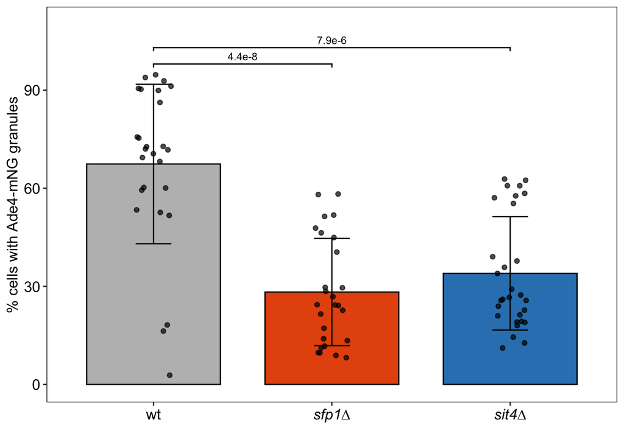

```r
annot2 = c("4.4e-8", "7.9e-6")

plot2 <- mean_sd %>% ggplot(aes(x= strain, y=mean))+
    geom_bar(aes(fill=strain),stat="identity", color="black",width = 0.75, position = position_dodge(width = 0.6)) +
  geom_errorbar(limits, width = 0.2, position = position_dodge(width=0.6)) +
  geom_signif(xmin = xmin, xmax =xmax, y_position =y_position, annotation = annot2, textsize = 3, tip_length = 0.01) +
  scale_fill_manual(values = c('#bdbdbd',"#e6550d","#3182bd"))+
  geom_jitter(foci_stat, mapping=aes(x=strain, y= pct_foci_cell),size = 1.5,
              alpha=0.7, width = 0.1, height = 0)+
  scale_x_discrete(labels=c("wt", "*sfp1∆*", "*sit4∆*")) +
  ylab("% cells with Ade4-mNG granules") +   ## y軸のラベル
  xlab("")+                   ## x軸のラベル
  ylim(0,110)+                  ## y軸のレンジ
  theme( axis.title.y = element_text(size=12), axis.text.y = element_text(size=12,color = "black"),
         axis.text.x = element_markdown(size = 12,colour = "black")
         ,legend.position = "none" #凡例を消す
         ,panel.border = element_rect(fill = NA, size = 0.5) # パネルを枠で囲む
         ,panel.background = element_blank()) #背景を白にする
plot2
```